# 🔧 Step 1: Data Preprocessing & Feature Engineering

## 📋 **Project Context**

This is the **second step** in our MMM pipeline. We take the cleaned individual datasets from Step 0 and prepare them for machine learning modeling by adding time-based features and handling outliers conservatively.

## 🎯 **Business Objective**

Transform cleaned datasets into modeling-ready format while preserving business patterns. For MMM, time features are critical for capturing seasonality and marketing effectiveness over time.

## 🔄 **What This Step Does**

### **1. Data Quality Verification**

- Load all 10 cleaned datasets from Step 0
- Verify data integrity (date ranges, missing values, basic statistics)
- Generate quality reports for each channel
- Ensure date consistency across all datasets

### **2. Conservative Outlier Treatment**

- **Philosophy**: Keep outliers unless clearly erroneous (MMM needs real business spikes)
- **Method**: Only cap outliers if they represent <2% of data
- **Rationale**: Marketing campaigns create legitimate spikes that shouldn't be removed
- **Example**: Black Friday sales spike = valid, not outlier to remove

### **3. Time Feature Engineering**

Critical for MMM success - creates features that capture:

#### **Basic Time Components**

- `year`, `month`, `week`, `quarter` - Linear time effects
- Business seasonality detection

#### **Cyclical Features** (Key for Seasonality)

- `month_sin`, `month_cos` - Smooth monthly seasonality
- `week_sin`, `week_cos` - Weekly patterns
- **Why Cyclical**: Captures that January is close to December (circular time)

#### **Business-Specific Features**

- `season` - Natural seasons (critical for ice cream business)
- `holiday_period` - Holiday seasons with increased consumption:
  - Christmas/New Year (Dec 25 - Jan 7)
  - Summer holidays (July-August)
  - Easter period (March-April)
- `is_month_end` - Payday effects (increased spending)

### **4. Feature Validation**

- Compare distributions before/after processing
- Ensure no data leakage or artificial patterns
- Validate that transformations make business sense

## 🎯 **MMM-Specific Design Decisions**

### **Why Conservative Outlier Handling?**

- **Marketing Reality**: Campaigns create legitimate spikes
- **Seasonal Business**: Ice cream has natural extreme variations
- **Model Learning**: MMM needs to learn from real marketing effects

### **Why These Time Features?**

- **Seasonality**: Ice cream is highly seasonal (summer peaks)
- **Marketing Timing**: Holiday campaigns are strategically timed
- **Baseline vs Media**: Time features help separate organic seasonality from media effects

## 📊 **Expected Outputs**

- 10 preprocessed datasets with 11+ new time features each
- Quality comparison reports (before/after)
- Feature distributions for validation
- Foundation for unified dataset creation

## 🔧 **Technical Implementation**

```python
import pandas as pd
import numpy as np
import os
import glob
import matplotlib.pyplot as plt
import seaborn as sns
from scipy import stats
import warnings
warnings.filterwarnings('ignore')

print("🔧 Data Preprocessing for Modeling")
print("=" * 40)

# Set plotting style
plt.style.use('default')
sns.set_palette("husl")
plt.rcParams['figure.figsize'] = (10, 6)
```

```
🔧 Data Preprocessing for Modeling
========================================
```

```python
# Load all cleaned datasets
interim_dir = '../data/interim'
cleaned_files = glob.glob(os.path.join(interim_dir, '*_basic_clean.csv'))

datasets = {}
for file_path in cleaned_files:
    filename = os.path.basename(file_path).replace('_basic_clean.csv', '')
    df = pd.read_csv(file_path)

    if 'date' in df.columns:
        df['date'] = pd.to_datetime(df['date'])

    datasets[filename] = df
    print(f"  📁 {filename}: {df.shape}")
```

```
  📁 promo: (47, 2)
  📁 radio_national: (156, 3)
  📁 sales: (156, 2)
  📁 email: (104, 2)
  📁 search: (156, 3)
  📁 tv_promo: (156, 3)
  📁 tv_branding: (156, 3)
  📁 ooh: (156, 2)
  📁 social: (156, 3)
  📁 radio_local: (156, 3)
```

```python
# Quick quality check
def quick_quality_check(df, name):
    print(f"\n✅ {name.upper()}:")
    print(f"  Shape: {df.shape}")

    if 'date' in df.columns:
        print(f"  Date range: {df['date'].min().date()} to {df['date'].max().date()}")

    missing = df.isnull().sum().sum()
    print(f"  Missing values: {missing}")

    # Check numeric columns
    numeric_cols = df.select_dtypes(include=[np.number]).columns.tolist()
    if 'date' in numeric_cols:
        numeric_cols.remove('date')

    for col in numeric_cols:
        if len(df[col].dropna()) > 0:
            data = df[col].dropna()
            Q1, Q3 = data.quantile([0.25, 0.75])
            IQR = Q3 - Q1
            outliers = data[(data < Q1 - 1.5*IQR) | (data > Q3 + 1.5*IQR)]
            outlier_pct = len(outliers) / len(data) * 100
            print(f"  {col}: outliers={outlier_pct:.1f}%")

for name, df in datasets.items():
    quick_quality_check(df, name)
```

```
✅ PROMO:
  Shape: (47, 2)
  Date range: 2022-01-10 to 2024-11-04
  Missing values: 0
  promotion_type: outliers=0.0%

✅ RADIO_NATIONAL:
  Shape: (156, 3)
  Date range: 2022-01-03 to 2024-12-23
  Missing values: 0
  radio_national_grps: outliers=0.0%
  radio_national_cost: outliers=0.0%

✅ SALES:
  Shape: (156, 2)
  Date range: 2022-01-03 to 2024-12-23
  Missing values: 0
  sales: outliers=0.0%

✅ EMAIL:
  Shape: (104, 2)
  Date range: 2022-01-03 to 2023-12-25
  Missing values: 0
  email_campaigns: outliers=5.8%

✅ SEARCH:
  Shape: (156, 3)
  Date range: 2022-01-03 to 2024-12-23
  Missing values: 0
  impressions: outliers=0.0%
  cost: outliers=0.0%

✅ TV_PROMO:
  Shape: (156, 3)
  Date range: 2022-01-03 to 2024-12-23
  Missing values: 0
  tv_promo_grps: outliers=0.0%
  tv_promo_cost: outliers=0.0%

✅ TV_BRANDING:
```

[output cut: 10 more lines]

```
  ooh_spend: outliers=3.8%

✅ SOCIAL:
  Shape: (156, 3)
  Date range: 2022-01-03 to 2024-12-23
  Missing values: 0
  impressions: outliers=0.0%
  costs: outliers=0.0%

✅ RADIO_LOCAL:
  Shape: (156, 3)
  Date range: 2022-01-03 to 2024-12-23
  Missing values: 0
  radio_local_grps: outliers=0.0%
  radio_local_cost: outliers=0.0%
```

```python
# Minimal outlier treatment
def handle_outliers_minimal(df, name):
    print(f"\n🎯 Outlier treatment: {name}")

    df_clean = df.copy()
    numeric_cols = df_clean.select_dtypes(include=[np.number]).columns.tolist()
    if 'date' in numeric_cols:
        numeric_cols.remove('date')

    outlier_info = {}

    for col in numeric_cols:
        data = df_clean[col].dropna()
        if len(data) == 0:
            continue

        Q1 = data.quantile(0.25)
        Q3 = data.quantile(0.75)
        IQR = Q3 - Q1
        lower_bound = Q1 - 1.5 * IQR
        upper_bound = Q3 + 1.5 * IQR

        outliers_mask = (df_clean[col] < lower_bound) | (df_clean[col] > upper_bound)
        outliers_count = outliers_mask.sum()

        if outliers_count > 0:
            outlier_pct = outliers_count / len(data) * 100

            # Conservative treatment: only cap if <2% outliers
            if outlier_pct < 2:
                df_clean.loc[df_clean[col] < lower_bound, col] = lower_bound
                df_clean.loc[df_clean[col] > upper_bound, col] = upper_bound
                print(f"  {col}: {outliers_count} outliers capped ({outlier_pct:.1f}%)")
            else:
                print(f"  {col}: {outliers_count} outliers kept ({outlier_pct:.1f}%)")

    return df_clean, outlier_info
```

```python
# Time feature engineering
def engineer_time_features(df, name):
    print(f"\n⚙️ Time features: {name}")

    if 'date' not in df.columns:
        print("  No date column - skipping")
        return df

    df_features = df.copy()

    # Basic time features
    df_features['year'] = df_features['date'].dt.year
    df_features['month'] = df_features['date'].dt.month
    df_features['week'] = df_features['date'].dt.isocalendar().week
    df_features['quarter'] = df_features['date'].dt.quarter

    # Cyclical features for seasonality
    df_features['month_sin'] = np.sin(2 * np.pi * df_features['month'] / 12)
    df_features['month_cos'] = np.cos(2 * np.pi * df_features['month'] / 12)
    df_features['week_sin'] = np.sin(2 * np.pi * df_features['week'] / 52)
    df_features['week_cos'] = np.cos(2 * np.pi * df_features['week'] / 52)

    # Business features
    def get_season(month):
        if month in [12, 1, 2]: return 'winter'
        elif month in [3, 4, 5]: return 'spring'
        elif month in [6, 7, 8]: return 'summer'
        else: return 'autumn'

    df_features['season'] = df_features['month'].apply(get_season)

    # Holiday periods
    def is_holiday_period(date):
        month, day = date.month, date.day
        if (month == 1 and day <= 7) or (month == 12 and day >= 25): return 1
        elif month in [7, 8]: return 1
        elif month in [3, 4] and 15 <= day <= 25: return 1
        else: return 0

    df_features['holiday_period'] = df_features['date'].apply(is_holiday_period)
    df_features['is_month_end'] = (df_features['date'].dt.day >= 25).astype(int)

    new_features = df_features.shape[1] - df.shape[1]
    print(f"  Added {new_features} time features")

    return df_features
```

```python
# Process all datasets
print(f"\n🔧 Processing all datasets...")

preprocessed_datasets = {}

for name, df in datasets.items():
    print(f"\n{'='*10} {name.upper()} {'='*10}")

    # Outlier treatment
    df_step1, _ = handle_outliers_minimal(df, name)

    # Time features
    df_final = engineer_time_features(df_step1, name)

    preprocessed_datasets[name] = df_final
    print(f"  Final shape: {df.shape} → {df_final.shape}")
```

```
🔧 Processing all datasets...

========== PROMO ==========

🎯 Outlier treatment: promo

⚙️ Time features: promo
  Added 11 time features
  Final shape: (47, 2) → (47, 13)

========== RADIO_NATIONAL ==========

🎯 Outlier treatment: radio_national

⚙️ Time features: radio_national
  Added 11 time features
  Final shape: (156, 3) → (156, 14)

========== SALES ==========

🎯 Outlier treatment: sales

⚙️ Time features: sales
  Added 11 time features
  Final shape: (156, 2) → (156, 13)

========== EMAIL ==========

🎯 Outlier treatment: email
  email_campaigns: 6 outliers kept (5.8%)

⚙️ Time features: email
  Added 11 time features
  Final shape: (104, 2) → (104, 13)

========== SEARCH ==========

🎯 Outlier treatment: search

⚙️ Time features: search
```

[output cut: 28 more lines]

```
========== SOCIAL ==========

🎯 Outlier treatment: social

⚙️ Time features: social
  Added 11 time features
  Final shape: (156, 3) → (156, 14)

========== RADIO_LOCAL ==========

🎯 Outlier treatment: radio_local

⚙️ Time features: radio_local
  Added 11 time features
  Final shape: (156, 3) → (156, 14)
```

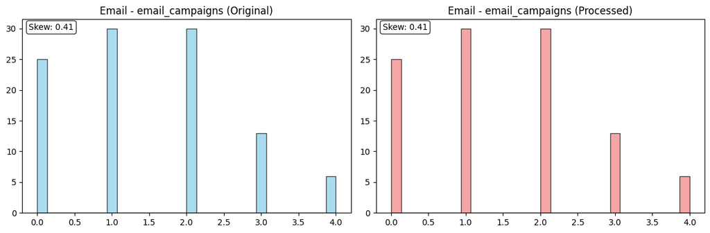

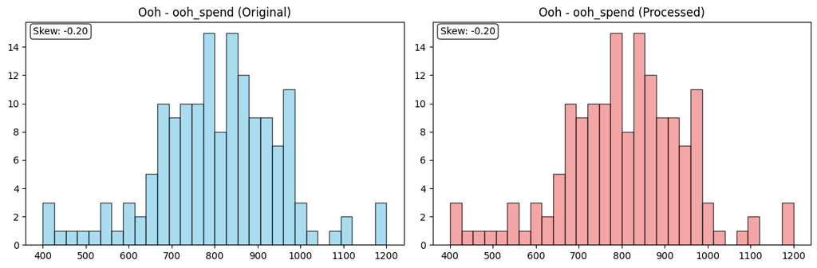

```python
# Distribution comparison for key datasets
def plot_key_distributions(original_datasets, preprocessed_datasets):
    # Only plot distributions for datasets with meaningful numeric variables
    key_datasets = ['email', 'facebook', 'google', 'ooh']  # Most important media channels

    for name in key_datasets:
        if name not in original_datasets:
            continue

        df_orig = original_datasets[name]
        df_proc = preprocessed_datasets[name]

        # Get main numeric column (usually the spend/impression/click column)
        numeric_cols = df_orig.select_dtypes(include=[np.number]).columns.tolist()
        if 'date' in numeric_cols:
            numeric_cols.remove('date')

        if not numeric_cols:
            continue

        # Plot the main variable
        main_col = numeric_cols[0]  # Usually the most important metric

        fig, axes = plt.subplots(1, 2, figsize=(12, 4))

        # Original
        data_orig = df_orig[main_col].dropna()
        axes[0].hist(data_orig, bins=30, alpha=0.7, color='skyblue', edgecolor='black')
        axes[0].set_title(f'{name.title()} - {main_col} (Original)')
        skew_orig = stats.skew(data_orig)
        axes[0].text(0.02, 0.98, f'Skew: {skew_orig:.2f}',
                    transform=axes[0].transAxes, verticalalignment='top',
                    bbox=dict(boxstyle='round', facecolor='white', alpha=0.8))

        # Processed
        data_proc = df_proc[main_col].dropna()
        axes[1].hist(data_proc, bins=30, alpha=0.7, color='lightcoral', edgecolor='black')
        axes[1].set_title(f'{name.title()} - {main_col} (Processed)')
        skew_proc = stats.skew(data_proc)
        axes[1].text(0.02, 0.98, f'Skew: {skew_proc:.2f}',
                    transform=axes[1].transAxes, verticalalignment='top',
                    bbox=dict(boxstyle='round', facecolor='white', alpha=0.8))

        plt.tight_layout()
        plt.show()

plot_key_distributions(datasets, preprocessed_datasets)
```

```python
# Save preprocessed datasets
processed_dir = '../data/processed'
os.makedirs(processed_dir, exist_ok=True)

print(f"\n💾 Saving preprocessed datasets...")

for name, df in preprocessed_datasets.items():
    output_path = os.path.join(processed_dir, f"{name}_preprocessed.csv")
    df.to_csv(output_path, index=False)
    print(f"  ✅ {name}_preprocessed.csv ({df.shape})")
```

```
💾 Saving preprocessed datasets...
  ✅ promo_preprocessed.csv ((47, 13))
  ✅ radio_national_preprocessed.csv ((156, 14))
  ✅ sales_preprocessed.csv ((156, 13))
```

```
  ✅ email_preprocessed.csv ((104, 13))
  ✅ search_preprocessed.csv ((156, 14))
  ✅ tv_promo_preprocessed.csv ((156, 14))
  ✅ tv_branding_preprocessed.csv ((156, 14))
  ✅ ooh_preprocessed.csv ((156, 13))
  ✅ social_preprocessed.csv ((156, 14))
  ✅ radio_local_preprocessed.csv ((156, 14))
```

```python
# Final summary
print(f"\n📋 PREPROCESSING COMPLETE")
print("=" * 40)

print(f"\nDatasets processed: {len(preprocessed_datasets)}")
for name, df in preprocessed_datasets.items():
    original_shape = datasets[name].shape
    final_shape = df.shape
    features_added = final_shape[1] - original_shape[1]
    print(f"  {name}: {original_shape} → {final_shape} (+{features_added} features)")

print(f"\n✅ Ready for next steps:")
print(f"  1. Data unification")
print(f"  2. EDA on unified dataset")
print(f"  3. Media Mix Modeling")
```

```
📋 PREPROCESSING COMPLETE
========================================

Datasets processed: 10
  promo: (47, 2) → (47, 13) (+11 features)
  radio_national: (156, 3) → (156, 14) (+11 features)
  sales: (156, 2) → (156, 13) (+11 features)
  email: (104, 2) → (104, 13) (+11 features)
  search: (156, 3) → (156, 14) (+11 features)
  tv_promo: (156, 3) → (156, 14) (+11 features)
  tv_branding: (156, 3) → (156, 14) (+11 features)
  ooh: (156, 2) → (156, 13) (+11 features)
  social: (156, 3) → (156, 14) (+11 features)
  radio_local: (156, 3) → (156, 14) (+11 features)

✅ Ready for next steps:
  1. Data unification
  2. EDA on unified dataset
  3. Media Mix Modeling
```

## Preprocessing Summary

**What was done:**

- Quality verification (no missing values, minimal outliers)
- Conservative outlier treatment (only extreme cases)
- Time feature engineering (cyclical features for seasonality)
- Business features (seasons, holidays, month-end effects)

**Output:**

- Individual preprocessed datasets saved in `data/processed/`
- Ready for unification and modeling

**Next:** Run data unification to combine all datasets